# Wrangle and Analyse Data

Code:

Now we need to merge the doggo,puppo,etc into one column

```python
#to merge all the columns at first we need to replace the none value with " "
#replace "None" with "" in each column
for x in ["doggo", "floofer", "pupper", "puppo"]:
    df_master_clean[x].replace("None", "", inplace = True)

#concatenate the columns
df_master_clean['dog_class'] = df_master_clean['doggo'].map(str) + df_master_clean[
    'floofer'].map(str) + df_master_clean['pupper'].map(str) + df_master_clean['puppo'].map(str)
df_master_clean.dog_class.value_counts()
```

```
                1379
pupper           164
doggo             53
puppo             21
floofer            7
doggopupper        7
doggopuppo         1
doggofloofer       1
Name: dog_class, dtype: int64
```

```python
#replace the leftover "" with np.nan
df_master_clean["dog_class"].replace("", np.nan, inplace = True)
```

```python
df_master_clean.dog_class.value_counts()
```

```
pupper          164
doggo            53
puppo            21
floofer           7
doggopupper       7
doggopuppo        1
doggofloofer      1
Name: dog_class, dtype: int64
```

```python
#count the occurrences of the pattern and show the rows with count > 1
df_master_clean.text.str.count(r'(\bpuppo\b|\bdoggo\b|\bfloofer\b|\bpupper\b)')[
    df_master_clean.text.str.count(r'(\bpuppo\b|\bdoggo\b|\bfloofer\b|\bpupper\b)') > 1]
```

```
191     2
531     3
575     2
889     2
956     2
1063    2
1113    2
1304    2
1340    2
1367    2
1653    2
1788    2
1828    2
1907    3
Name: text, dtype: int64
```

```python
df_master_clean["dog_class_re"] = df_master_clean.text.str.extract(
    r'(\bpuppo\b|\bdoggo\b|\bfloofer\b|\bpupper\b)', expand = True)
```

```python
pd.set_option('display.max_colwidth', -1)

#find the differences of the extract
df_master_clean[["text","dog_class", "dog_class_re"]].dropna(subset = ["dog_class_re"]).query("dog_class != dog_class_re")
```

|  | text | dog_class | dog_class_re |
| --- | --- | --- | --- |
| 191 | Here's a puppo participating in the #ScienceMarch. Cleverly disguising her own doggo agenda. 13/10 would keep the planet habitable for https://t.co/cMhq16isel | doggopuppo | puppo |
| 200 | At first I thought this was a shy doggo, but it's actually a Rare Canadian Floofer Owl. Amateurs would confuse the two. 11/10 only send dogs https://t.co/TXdT3tmuYk | doggofloofer | doggo |
| 531 | Here we have Burke (pupper) and Dexter (doggo). Pupper wants to be exactly like doggo. Both 12/10 would pet at same time https://t.co/ANBpEYHaho | doggopupper | pupper |
| 575 | This is Bones. He's being haunted by another doggo of roughly the same size. 12/10 deep breaths pupper everything's fine https://t.co/55Dqe0SJNj | doggopupper | doggo |
| 889 | Meet Maggie &amp; Lila. Maggie is the doggo, Lila is the pupper. They are sisters. Both 12/10 would pet at the same time https://t.co/MYwR4DQKll | doggopupper | doggo |
| 956 | Please stop sending it pictures that don't even have a doggo or pupper in them. Churlish af. 5/10 neat couch tho https://t.co/u2c9c7qSg8 | doggopupper | doggo |
| 1063 | This is just downright precious af. 12/10 for both pupper and doggo https://t.co/o5J479bZUC | doggopupper | pupper |
| 1113 | Like father (doggo), like son (pupper). Both 12/10 https://t.co/pG2inLaOda | doggopupper | doggo |

```python
#I read the text and corrected the dog class
df_master_clean.loc[191, "dog_class"] = "puppo"
df_master_clean.loc[200, "dog_class"] = "floofer"
df_master_clean.loc[531, "dog_class"] = np.nan
df_master_clean.loc[575, "dog_class"] = "pupper"
df_master_clean.loc[889, "dog_class"] = np.nan
df_master_clean.loc[956, "dog_class"] = np.nan
df_master_clean.loc[1063, "dog_class"] = np.nan
df_master_clean.loc[1113, "dog_class"] = np.nan
```

```python
df_master_clean[["text","dog_class", "dog_class_re"]].dropna(subset = ["dog_class_re"]).query("dog_class != dog_class_re")
```

|  | text | dog_class | dog_class_re |
| --- | --- | --- | --- |
| 200 | At first I thought this was a shy doggo, but it's actually a Rare Canadian Floofer Owl. Amateurs would confuse the two. 11/10 only send dogs https://t.co/TXdT3tmuYk | floofer | doggo |
| 531 | Here we have Burke (pupper) and Dexter (doggo). Pupper wants to be exactly like doggo. Both 12/10 would pet at same time https://t.co/ANBpEYHaho | NaN | pupper |
| 575 | This is Bones. He's being haunted by another doggo of roughly the same size. 12/10 deep breaths pupper everything's fine https://t.co/55Dqe0SJNj | pupper | doggo |
| 889 | Meet Maggie &amp; Lila. Maggie is the doggo, Lila is the pupper. They are sisters. Both 12/10 would pet at the same time https://t.co/MYwR4DQKll | NaN | doggo |
| 956 | Please stop sending it pictures that don't even have a doggo or pupper in them. Churlish af. 5/10 neat couch tho https://t.co/u2c9c7qSg8 | NaN | doggo |
| 1063 | This is just downright precious af. 12/10 for both pupper and doggo https://t.co/o5J479bZUC | NaN | pupper |
| 1113 | Like father (doggo), like son (pupper). Both 12/10 https://t.co/pG2inLaOda | NaN | doggo |

```python
#drop the columns out
df_master_clean.drop(["doggo", "floofer", "pupper", "puppo", "dog_class_re"], inplace = True, axis = 1)
```

Test:

```python
#count the occurrences of the pattern and show the rows with count > 1
df_master_clean[["text", "dog_class"]].loc[
    df_master_clean.text.str.count(r'(\bpuppo\b|\bdoggo\b|\bfloofer\b|\bpupper\b)')[
        df_master_clean.text.str.count(r'(\bpuppo\b|\bdoggo\b|\bfloofer\b|\bpupper\b)') > 1].index]
```

|  | text | dog_class |
| --- | --- | --- |
| 191 | Here's a puppo participating in the #ScienceMarch. Cleverly disguising her own doggo agenda. 13/10 would keep the planet habitable for https://t.co/cMhq16isel | puppo |
| 531 | Here we have Burke (pupper) and Dexter (doggo). Pupper wants to be exactly like doggo. Both 12/10 would pet at same time https://t.co/ANBpEYHaho | NaN |
| 575 | This is Bones. He's being haunted by another doggo of roughly the same size. 12/10 deep breaths pupper everything's fine https://t.co/55Dqe0SJNj | pupper |
| 889 | Meet Maggie &amp; Lila. Maggie is the doggo, Lila is the pupper. They are sisters. Both 12/10 would pet at the same time https://t.co/MYwR4DQKll | NaN |
| 956 | Please stop sending it pictures that don't even have a doggo or pupper in them. Churlish af. 5/10 neat couch tho https://t.co/u2c9c7qSg8 | NaN |
| 1063 | This is just downright precious af. 12/10 for both pupper and doggo https://t.co/o5J479bZUC | NaN |
| 1113 | Like father (doggo), like son (pupper). Both 12/10 https://t.co/pG2inLaOda | NaN |
| 1304 | "I shall trip the big pupper with leash. Big pupper will never see it coming. I am a genius." Both 11/10 https://t.co/uQsCJ8pf51 | pupper |
| 1340 | Here is a heartbreaking scene of an incredible pupper being laid to rest. 10/10 RIP pupper https://t.co/81mvJ0rGRu | pupper |
| 1367 | This is Sansa. She's gotten too big for her chair. Not so smol anymore. 11/10 once a pupper, always a pupper https://t.co/IpAoztle2s | pupper |
| 1653 | "Hello forest pupper I am house pupper welcome to my abode" (8/10 for both) https://t.co/qFD8217fUT | pupper |
| 1788 | Reckless pupper here. Not even looking at road. Absolute menace. No regard for fellow pupper lives. 10/10 still cute https://t.co/96IBkOYB7j | pupper |
| 1828 | All this pupper wanted to do was go skiing. No one told him about the El Niño. Poor pupper. 10/10 maybe next year https://t.co/fTgbq1UBR9 | pupper |
| 1907 | This pupper just wants a belly rub. This pupper has nothing to do w the tree being sideways now. 10/10 good pupper https://t.co/AyJ7Ohk71f | pupper |

All looks correct

Define:

Remove the wrong names of name column

Code:

```python
#here we will remove all the wrong names
for x in ["None", "a", "by", "the"]:
    df_master_clean["name"].replace(x, np.nan, inplace = True)
```

```python
#to convert all the lowercase into uppercase
df["name"]= df["name"].str.upper().str.title()
```

Test:

```python
df_master_clean.name.value_counts()
```

```
Cooper     10
Lucy       9
Charlie    9
Tucker     9
Oliver     9
          ..
Jimison    1
Laela      1
Carll      1
Beckham    1
Ralphé     1
Name: name, Length: 833, dtype: int64
```

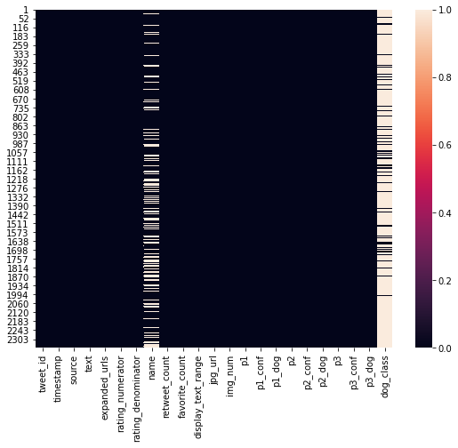

```python
fig, ax = plt.subplots(figsize = (9,7))
ax = sns.heatmap(df_master_clean.isnull(), vmin = 0, vmax = 1)
```

Define:

Reduce the prediction columns into two - breed and conf

Code:

```python
#now we will reduce the columns
def get_attr(x):
    """
    INPUT:
        Columns in this order: Check1, Result1, Check2, Result2, Result3
    OUTPUT:
        Results based on the check in this columns
    """
    if x[0] == True:
        return x[1]
    elif x[2] == True:
        return x[3]
    else:
        return x[4]

df_master_clean["breed"] = df_master_clean[["p1_dog", "p1", "p2_dog", "p2", "p3"]].apply(get_attr, axis = 1)
df_master_clean["conf"] = df_master_clean[["p1_dog", "p1_conf", "p2_dog", "p2_conf", "p3_conf"]].apply(get_attr, axis = 1)
```

```python
df_master_clean.iloc[:, 12:]
```

|  | img_num | p1 | p1_conf | p1_dog | p2 | p2_conf | p2_dog | p3 | p3_conf | p3_dog | dog_class | breed | conf |
| --- | --- | --- | --- | --- | --- | --- | --- | --- | --- | --- | --- | --- | --- |
| 1 | 1 | Chihuahua | 0.323581 | True | Pekinese | 0.090647 | True | papillon | 0.068957 | True | NaN | Chihuahua | 0.323581 |
| 2 | 1 | Chihuahua | 0.716012 | True | malamute | 0.078253 | True | kelpie | 0.031379 | True | NaN | Chihuahua | 0.716012 |
| 3 | 1 | paper_towel | 0.170278 | False | Labrador_retriever | 0.168086 | True | spatula | 0.040836 | False | NaN | Labrador_retriever | 0.168086 |
| 4 | 2 | basset | 0.555712 | True | English_springer | 0.225770 | True | German_short-haired_pointer | 0.175219 | True | NaN | basset | 0.555712 |
| 5 | 1 | Chesapeake_Bay_retriever | 0.425595 | True | Irish_terrier | 0.116317 | True | Indian_elephant | 0.076902 | False | NaN | Chesapeake_Bay_retriever | 0.425595 |
| ... | ... | ... | ... | ... | ... | ... | ... | ... | ... | ... | ... | ... | ... |
| 2351 | 1 | miniature_pinscher | 0.560311 | True | Rottweiler | 0.243682 | True | Doberman | 0.154629 | True | NaN | miniature_pinscher | 0.560311 |
| 2352 | 1 | Rhodesian_ridgeback | 0.408143 | True | redbone | 0.360687 | True | miniature_pinscher | 0.222752 | True | NaN | Rhodesian_ridgeback | 0.408143 |
| 2353 | 1 | German_shepherd | 0.596461 | True | malinois | 0.138584 | True | bloodhound | 0.116197 | True | NaN | German_shepherd | 0.596461 |
| 2354 | 1 | redbone | 0.506826 | True | miniature_pinscher | 0.074192 | True | Rhodesian_ridgeback | 0.072010 | True | NaN | redbone | 0.506826 |
| 2355 | 1 | Welsh_springer_spaniel | 0.465074 | True | collie | 0.156665 | True | Shetland_sheepdog | 0.061428 | True | NaN | Welsh_springer_spaniel | 0.465074 |

1633 rows × 13 columns

```python
#drop the reduced columns
df_master_clean.drop(df_master_clean.columns[12:21], inplace = True, axis = 1)
```

Test:

```python
df_master_clean.head()
```

|  | tweet_id | timestamp | source | text | expanded_urls | rating_numerator | rating_denominator | name | retweet_count | favorite_count | display_text_range | jpg_url | p3_dog | dog_class | breed | conf |
| --- | --- | --- | --- | --- | --- | --- | --- | --- | --- | --- | --- | --- | --- | --- | --- | --- |
| 1 | 892177421306343426 | 2017-08-01 00:17:27+00:00 | Twitter for iPhone | This is Tilly. She's just checking pup on you. Hopes you're doing ok. If not, she's available for pats, snugs, boops, the whole bit. 13/10 https://t.co/0Xxu71qeIV | https://twitter.com/dog_rates/status/892177421306343426/photo/1 | 13.0 | 10.0 | Tilly | 5712 | 31283 | [0, 138] | https://pbs.twimg.com/media/DGGmoV4XsAAUL6n.jpg | True | NaN | Chihuahua | 0.323581 |
| 2 | 891815181378084864 | 2017-07-31 00:18:03+00:00 | Twitter for iPhone | This is Archie. He is a rare Norwegian Pouncing Corgo. Lives in the tall grass. You never know when one may strike. 12/10 https://t.co/wUnZnhtVJB | https://twitter.com/dog_rates/status/891815181378084864/photo/1 | 12.0 | 10.0 | Archie | 3786 | 23553 | [0, 121] | https://pbs.twimg.com/media/DGBdLU1WsAANxJ9.jpg | True | NaN | Chihuahua | 0.716012 |
| 3 | 891689557279858688 | 2017-07-30 15:58:51+00:00 | Twitter for iPhone | This is Darla. She commenced a snooze mid meal. 13/10 happens to the best of us https://t.co/tD36da7qLQ | https://twitter.com/dog_rates/status/891689557279858688/photo/1 | 13.0 | 10.0 | Darla | 7878 | 39567 | [0, 79] | https://pbs.twimg.com/media/DF_q7IAWsAEuuN8.jpg | False | NaN | Labrador_retriever | 0.168086 |
| 4 | 891327558926688256 | 2017-07-29 16:00:24+00:00 | Twitter for iPhone | This is Franklin. He would like you to stop calling him "cute." He is a very fierce shark and should be respected as such. 12/10 #BarkWeek https://t.co/AtUZn91f7f | https://twitter.com/dog_rates/status/891327558926688256/photo/1,https://twitter.com/dog_rates/status/891327558926688256/photo/1 | 12.0 | 10.0 | Franklin | 8498 | 37794 | [0, 138] | https://pbs.twimg.com/media/DF6hr6BUMAAzZgT.jpg | True | NaN | basset | 0.555712 |
| 5 | 891087950875897856 | 2017-07-29 00:08:17+00:00 | Twitter for iPhone | Here we have a majestic great white breaching off South Africa's coast. Absolutely h*ckin breathtaking. 13/10 (IG: tucker_marlo) #BarkWeek https://t.co/kQ04fDDRmh | https://twitter.com/dog_rates/status/891087950875897856/photo/1 | 13.0 | 10.0 | NaN | 2847 | 19038 | [0, 138] | https://pbs.twimg.com/media/DF3HwyEWsAABqE6.jpg | False | NaN | Chesapeake_Bay_retriever | 0.425595 |

Define:

Clean the new breed column by replacing the "_" with a whitespace and make them all lowercase

Test:

```python
#replace "_" with " "
df_master_clean.breed = df_master_clean.breed.str.replace("_", " ")
```

```python
df_master_clean.breed
```

```
1       Chihuahua
2       Chihuahua
3       Labrador retriever
4       basset
5       Chesapeake Bay retriever
                  ...
2351    miniature pinscher
2352    Rhodesian ridgeback
2353    German shepherd
2354    redbone
2355    Welsh springer spaniel
Name: breed, Length: 1633, dtype: object
```

Test:

```python
df_master_clean.breed = df_master_clean.breed.str.lower()

df_master_clean.breed.value_counts().head(10)
```

```
golden retriever      154
labrador retriever    103
pembroke              93
chihuahua             87
pug                   62
toy poodle            49
chow                  48
samoyed               41
pomeranian            39
malamute              33
Name: breed, dtype: int64
```

```python
#reset index to match with the real amount of rows
df_master_clean.reset_index(drop = True, inplace = True)
```

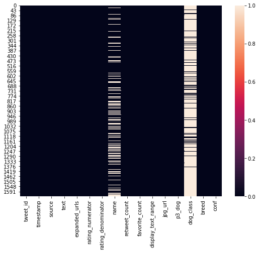

```python
fig, ax = plt.subplots(figsize = (9,7))
ax = sns.heatmap(df_master_clean.isnull(), vmin = 0, vmax = 1)
```

Here we can see that our data is much cleaner now

```python
#save the data to a *.csv file
df_master_clean.to_csv('twitter_archive_master.csv', index = False)
```

# Data Analysis

Questions:

```
1. Based on the predicted, most likely dog breed: Which breed gets retweeted and favorited the most overall?
2. How did the account develop (speaking about number of tweets, retweets, favorites, image number and length of the tweets)?
3. Is there a pattern visible in the timing of the tweets?
```

```python
#read in the master csv
df = pd.read_csv("twitter_archive_master.csv")
df.head()
```

|  | tweet_id | timestamp | source | text | expanded_urls | rating_numerator | rating_denominator | name | retweet_count | favorite_count | display_text_range | jpg_url | p3_dog | dog_class | breed | conf |
| --- | --- | --- | --- | --- | --- | --- | --- | --- | --- | --- | --- | --- | --- | --- | --- | --- |
| 0 | 892177421306343426 | 2017-08-01 00:17:27+00:00 | Twitter for iPhone | This is Tilly. She's just checking pup on you. Hopes you're doing ok. If not, she's available for pats, snugs, boops, the whole bit. 13/10 https://t.co/0Xxu71qeIV | https://twitter.com/dog_rates/status/892177421306343426/photo/1 | 13.0 | 10.0 | Tilly | 5712 | 31283 | [0, 138] | https://pbs.twimg.com/media/DGGmoV4XsAAUL6n.jpg | True | NaN | chihuahua | 0.323581 |
| 1 | 891815181378084864 | 2017-07-31 00:18:03+00:00 | Twitter for iPhone | This is Archie. He is a rare Norwegian Pouncing Corgo. Lives in the tall grass. You never know when one may strike. 12/10 https://t.co/wUnZnhtVJB | https://twitter.com/dog_rates/status/891815181378084864/photo/1 | 12.0 | 10.0 | Archie | 3786 | 23553 | [0, 121] | https://pbs.twimg.com/media/DGBdLU1WsAANxJ9.jpg | True | NaN | chihuahua | 0.716012 |
| 2 | 891689557279858688 | 2017-07-30 15:58:51+00:00 | Twitter for iPhone | This is Darla. She commenced a snooze mid meal. 13/10 happens to the best of us https://t.co/tD36da7qLQ | https://twitter.com/dog_rates/status/891689557279858688/photo/1 | 13.0 | 10.0 | Darla | 7878 | 39567 | [0, 79] | https://pbs.twimg.com/media/DF_q7IAWsAEuuN8.jpg | False | NaN | labrador retriever | 0.168086 |
| 3 | 891327558926688256 | 2017-07-29 16:00:24+00:00 | Twitter for iPhone | This is Franklin. He would like you to stop calling him "cute." He is a very fierce shark and should be respected as such. 12/10 #BarkWeek https://t.co/AtUZn91f7f | https://twitter.com/dog_rates/status/891327558926688256/photo/1,https://twitter.com/dog_rates/status/891327558926688256/photo/1 | 12.0 | 10.0 | Franklin | 8498 | 37794 | [0, 138] | https://pbs.twimg.com/media/DF6hr6BUMAAzZgT.jpg | True | NaN | basset | 0.555712 |
| 4 | 891087950875897856 | 2017-07-29 00:08:17+00:00 | Twitter for iPhone | Here we have a majestic great white breaching off South Africa's coast. Absolutely h*ckin breathtaking. 13/10 (IG: tucker_marlo) #BarkWeek https://t.co/kQ04fDDRmh | https://twitter.com/dog_rates/status/891087950875897856/photo/1 | 13.0 | 10.0 | NaN | 2847 | 19038 | [0, 138] | https://pbs.twimg.com/media/DF3HwyEWsAABqE6.jpg | False | NaN | chesapeake bay retriever | 0.425595 |

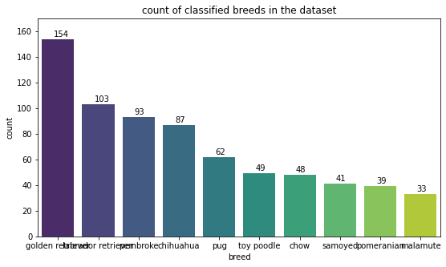

```python
fig, ax = plt.subplots(figsize = (9,5))
ax = sns.countplot(x = "breed", data = df, order=df.breed.value_counts().iloc[:10].index, palette = "viridis")
ax.set_title("count of classified breeds in the dataset");

ax.set_ylim(0, 170)
#https://stackoverflow.com/questions/33179122/seaborn-countplot-with-frequencies
for p in ax.patches:
    ax.annotate('{:.0f}'.format(p.get_height()), (p.get_x()+0.3, p.get_height()+2))
```

So, we can see that the dogs mostly reviewd is golden retriever and the second is labrador

```python
df_breed_group = df[["retweet_count", "favorite_count", "breed"]].groupby("breed", as_index = False).sum()
```

```python
df_breed_group.sort_values("retweet_count", ascending = False).head(10)
```

|  | breed | retweet_count | favorite_count |
| --- | --- | --- | --- |
| 45 | golden retriever | 505839 | 1765712 |
| 62 | labrador retriever | 347651 | 1123149 |
| 80 | pembroke | 258538 | 969622 |
| 27 | chihuahua | 213031 | 679620 |
| 88 | samoyed | 170619 | 517398 |
| 41 | french bulldog | 144684 | 564115 |
| 30 | cocker spaniel | 127336 | 368344 |
| 28 | chow | 117604 | 419155 |
| 82 | pug | 103755 | 350579 |
| 81 | pomeranian | 99768 | 294519 |

```python
df_breed_group.sort_values("favorite_count", ascending = False).head(10)
```

|  | breed | retweet_count | favorite_count |
| --- | --- | --- | --- |
| 45 | golden retriever | 505839 | 1765712 |
| 62 | labrador retriever | 347651 | 1123149 |
| 80 | pembroke | 258538 | 969622 |
| 27 | chihuahua | 213031 | 679620 |
| 41 | french bulldog | 144684 | 564115 |
| 88 | samoyed | 170619 | 517398 |
| 28 | chow | 117604 | 419155 |
| 30 | cocker spaniel | 127336 | 368344 |
| 82 | pug | 103755 | 350579 |
| 66 | malamute | 96978 | 327871 |

Here also we can see that the golden retriever and the labrader tops the list

```python
df_breed_group["sum"] = df_breed_group["retweet_count"] + df_breed_group["favorite_count"]

df_breed_group.sort_values("sum", ascending = False).head(10)
```

|  | breed | retweet_count | favorite_count | sum |
| --- | --- | --- | --- | --- |
| 45 | golden retriever | 505839 | 1765712 | 2271551 |
| 62 | labrador retriever | 347651 | 1123149 | 1470800 |
| 80 | pembroke | 258538 | 969622 | 1228160 |
| 27 | chihuahua | 213031 | 679620 | 892651 |
| 41 | french bulldog | 144684 | 564115 | 708799 |
| 88 | samoyed | 170619 | 517398 | 688017 |
| 28 | chow | 117604 | 419155 | 536759 |
| 30 | cocker spaniel | 127336 | 368344 | 495680 |
| 82 | pug | 103755 | 350579 | 454334 |
| 66 | malamute | 96978 | 327871 | 424849 |

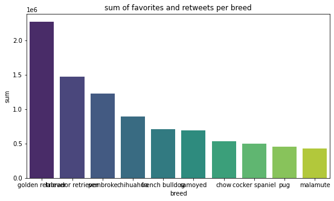

```python
fig, ax = plt.subplots(figsize = (9,5))
ax = sns.barplot(x = "breed", y = "sum", data = df_breed_group.sort_values("sum", ascending=False).iloc[:10], palette = "viridis")
ax.set_title("sum of favorites and retweets per breed");
```

```python
df[["retweet_count", "favorite_count", "breed"]].sort_values("retweet_count", ascending = False).head(5)
```

|  | retweet_count | favorite_count | breed |
| --- | --- | --- | --- |
| 678 | 77999 | 156520 | labrador retriever |
| 705 | 57820 | 115635 | eskimo dog |
| 356 | 56865 | 120909 | chihuahua |
| 271 | 43938 | 133322 | lakeland terrier |
| 53 | 40676 | 99428 | english springer |

```python
df[["retweet_count", "favorite_count", "breed"]].sort_values("favorite_count", ascending = False).head(5)
```

|  | retweet_count | favorite_count | breed |
| --- | --- | --- | --- |
| 678 | 77999 | 156520 | labrador retriever |
| 271 | 43938 | 133322 | lakeland terrier |
| 356 | 56865 | 120909 | chihuahua |
| 99 | 33033 | 116636 | french bulldog |
| 705 | 57820 | 115635 | eskimo dog |

```python
#see the mean average rating
df_breed_group_mean = df[["rating_numerator", "breed"]].groupby("breed", as_index = False).mean()
```

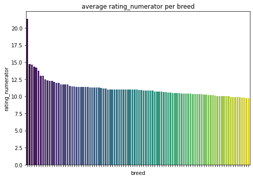

```python
fig, ax = plt.subplots(figsize = (7,5))
ax = sns.barplot(x = "breed", y = "rating_numerator", data = df_breed_group_mean.sort_values("rating_numerator", ascending = False).iloc[:100], palette = "viridis")
ax.set_title("average rating_numerator per breed");
ax.xaxis.set_ticklabels([])
plt.tight_layout()
```

```python
df_breed_group_mean.sort_values("rating_numerator", ascending = False).head(10)
```

|  | breed | rating_numerator |
| --- | --- | --- |
| 96 | soft-coated wheaten terrier | 21.357143 |
| 109 | west highland white terrier | 14.687500 |
| 48 | great pyrenees | 14.666667 |
| 16 | borzoi | 14.333333 |
| 28 | chow | 14.166667 |
| 62 | labrador retriever | 13.728155 |
| 4 | australian terrier | 13.000000 |
| 18 | bouvier des flandres | 13.000000 |
| 87 | saluki | 12.500000 |
| 21 | briard | 12.333333 |

```python
df[["breed", "rating_numerator"]].sort_values("rating_numerator", ascending = False).head(5)
```

|  | breed | rating_numerator |
| --- | --- | --- |
| 583 | labrador retriever | 165.0 |
| 1222 | chow | 144.0 |
| 1116 | soft-coated wheaten terrier | 121.0 |
| 823 | golden retriever | 99.0 |
| 1269 | labrador retriever | 88.0 |

```python
df.query("breed != 'soft-coated wheaten terrier'").rating_numerator.mean()
```

```
11.261754169240271
```

```python
df_time = df.copy()
df_time.info()
```

```
<class 'pandas.core.frame.DataFrame'>
RangeIndex: 1633 entries, 0 to 1632
Data columns (total 16 columns):
 #   Column              Non-Null Count  Dtype
---  ------              --------------  -----
 0   tweet_id            1633 non-null   int64
 1   timestamp           1633 non-null   object
 2   source              1633 non-null   object
 3   text                1633 non-null   object
 4   expanded_urls       1633 non-null   object
 5   rating_numerator    1633 non-null   float64
 6   rating_denominator  1633 non-null   float64
 7   name                1190 non-null   object
 8   retweet_count       1633 non-null   int64
 9   favorite_count      1633 non-null   int64
 10  display_text_range  1633 non-null   object
 11  jpg_url             1633 non-null   object
 12  p3_dog              1633 non-null   bool
 13  dog_class           249 non-null    object
 14  breed               1633 non-null   object
 15  conf                1633 non-null   float64
dtypes: bool(1), float64(3), int64(3), object(9)
memory usage: 193.1+ KB
```

```python
df_time.timestamp = pd.to_datetime(df_time.timestamp)
```

```python
df_time["dow"] = df_time["timestamp"].apply(lambda x: x.dayofweek)
```

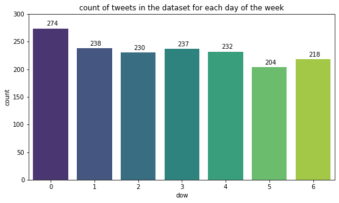

```python
fig, ax = plt.subplots(figsize = (9,5))
ax = sns.countplot(x = "dow", data = df_time, palette = "viridis")
ax.set_title("count of tweets in the dataset for each day of the week");

ax.set_ylim(0, 300)
#https://stackoverflow.com/questions/33179122/seaborn-countplot-with-frequencies
for p in ax.patches:
    ax.annotate('{:.0f}'.format(p.get_height()), (p.get_x()+0.3, p.get_height()+5))
```

we can see that the most tweets are posted on Monday. For tuesday to friday it is nearly the same number of posts. On the weekend the Twitter profile tweets a little bil less

```python
df_time.timestamp.min()
```

```
Timestamp('2015-11-15 22:32:08+0000', tz='UTC')
```

```python
df_time.timestamp.max()
```

```
Timestamp('2017-08-01 00:17:27+0000', tz='UTC')
```

The dataset contains data from 2015 to 2017

```python
#get the month out of the timestamp
df_time["month"] = df_time["timestamp"].apply(lambda x: x.month)
#get the year out of the timestamp
df_time["year"] = df_time["timestamp"].apply(lambda x: x.year)
#get the hour out of the timestamp
df_time["hour"] = df_time["timestamp"].apply(lambda x: x.hour)
```

For the first graph I only want to take a look on the full year 2016

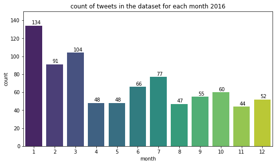

```python
fig, ax = plt.subplots(figsize = (9,5))
ax = sns.countplot(x = "month", data = df_time.query("year == 2016"), palette = "viridis")
ax.set_title("count of tweets in the dataset for each month 2016");


ax.set_ylim(0,150)
for p in ax.patches:
    ax.annotate('{:.0f}'.format(p.get_height()), (p.get_x()+0.3, p.get_height()+1.5))
```

Over the timeperiod of 2016 the number of post per months decreased. It went from 134 tweets in January to 52 in December. Does this mean, that the performance of this account is also decreasing?

```python
df_time['month_year'] = pd.to_datetime(df["timestamp"]).dt.to_period('M')
```

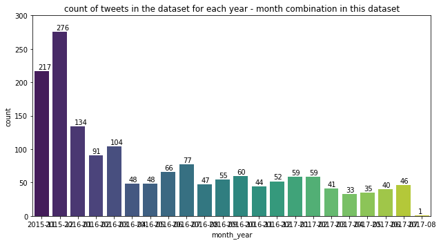

```python
fig, ax = plt.subplots(figsize = (9,5))
ax = sns.countplot(x = "month_year", data = df_time.sort_values("month_year"), palette = "viridis", )
ax.set_title("count of tweets in the dataset for each year - month combination in this dataset");

ax.set_ylim(0, 300)

for p in ax.patches:
    ax.annotate('{:.0f}'.format(p.get_height()), (p.get_x()+0.2, p.get_height()+3))

plt.tight_layout()
```

If we look at it over the whole timeperiod it becomes even more clear. In April 2016 the number of tweets dropped and since then it has a relatively stable level. To see if the performance of the Account decreased we will take a look on the favorites and retweets that the posts get.

```python
df_time_groupby = df_time.groupby("month_year", as_index = False).sum()
```

```python
df_time_groupby.head()
```

|  | month_year | tweet_id | rating_numerator | rating_denominator | retweet_count | favorite_count | p3_dog | conf | dow | month | year | hour |
| --- | --- | --- | --- | --- | --- | --- | --- | --- | --- | --- | --- | --- |
| 0 | 2015-11 | 1.450925e+20 | 2049.00 | 2170.0 | 92890.0 | 237891.0 | 187.0 | 105.165214 | 635.0 | 2387.0 | 437255.0 | 1833.0 |
| 1 | 2015-12 | 1.866097e+20 | 2986.26 | 2940.0 | 390890.0 | 962589.0 | 237.0 | 143.884391 | 783.0 | 3312.0 | 556140.0 | 2514.0 |
| 2 | 2016-01 | 9.218872e+19 | 1505.00 | 1440.0 | 156315.0 | 446701.0 | 112.0 | 71.353070 | 418.0 | 134.0 | 270144.0 | 1082.0 |
| 3 | 2016-02 | 6.362919e+19 | 1033.00 | 980.0 | 114418.0 | 331954.0 | 80.0 | 49.415261 | 256.0 | 182.0 | 183456.0 | 737.0 |
| 4 | 2016-03 | 7.376839e+19 | 1298.00 | 1230.0 | 141137.0 | 424219.0 | 93.0 | 62.738141 | 310.0 | 312.0 | 209664.0 | 889.0 |